# Initiation aux modèles longitudinaux - Didanosine vs Zalcitabine pour des patients atteints de VIH

Hadrien Cadiou

2023-10-18

# Introduction

L’évaluation de la réponse aux traitements est réalisée par la mesure du nombre de lymphocythes T CD4+ (cellules cibles du virus et acteurs majeur de la réponse immunologique). L’analyse de l’évolution de ces marqueurs prédictifs de l’évolution clinique de la maladie permet de décrire l’histoire naturelle de la maladie mais également d’évaluer l’efficacité des traitements.

Dans de nombreuses maladies, l’examen des mesures répétées de marqueurs biologiques permet de suivre l’évolution de l’état du patient et d’anticiper la survenue d’événements cliniques.

# I - Problématique clinique:

On se demande donc, si un traitement est plus (ddC ou ddl) est plus efficace qu’un autre ? Est-ce qu’il y a un effet du traitement ? C’est à dire est-ce que le nombre de CD4 augmente au cours du temps ou diminue ? Si le traitement est efficace on s’attend a voir plus de CD4.

# II- Modélisation:

Nous allons nous interesser aux deux modèles linéaires à effets mixtes avec intercept et pente aléatoire suivants : **Modèle 1 :**
$$CD4_{ij} = \beta_0 + \beta_1
\times \text{obstime}_{ij} + \beta_2 \times \text{drug}_{ij} + b_{i0} +
b_{i1} \times \text{obstime}_{ij} + \varepsilon_{ij}$$
Dans ce premier modèle nous tenons compte de la variabilité individuelle des patients (terme $b_{i0}$) en taux de CD4 (racine carrée du nombre de CD4, dans ces données). Nous avons ensuite la variable ‘obstime’, modélisant l’augmentation ou la diminution du nombre de CD4 au cours du temps. Par ailleurs certains médicaments pourraient augmenter/diminuer le nombre de cellules CD4 avec la variable ‘drug’, c’est ce que nous appellerons “l’effet du traitement” Nous avons également introduit le terme ‘$b_{i1}\times \text{obstime}_{ij}$’ pour modéliser l’aléatoirité de l’augmentation/diminution du nombre de CD4, ce qui permet de capturer de manière unique la façon dont les cellules CD4 des patients réagissent au cours du temps. Enfin, malgré tous ces facteurs, il y a toujours quelques variations inexpliquées, comme des erreurs de mesure ou d’autres facteurs inconnus. Nous les appelons ‘erreurs’ dans notre modèle.

**Modèle 2:**

$$CD4_{ij} = \beta_{0} + \beta_{1} \times
\text{obstime}_{ij} + \beta_{2} \times \text{drug}_{ij} + \beta_{3}
\times \text{obstime}_{ij} \times \text{drug}_{ij} + b_{i0} + b_{i1}
\times \text{obstime}_{ij} + \varepsilon_{ij}$$
Dans le Modèle 2, on retrouve les même termes que le modèle 1, mais on ajoute en plus un terme d’interaction $\text{obstime}\times\text{drug}$, ce nous permet de voir si l’effet du temps sur les cellules CD4 est modifié par le type de traitement. Par exemple, pour un traitement donné, le nombre de cellules CD4 pourrait augmenter plus rapidement ou plus lentement avec le temps par rapport à un autre traitement ce qui nous permettra de répondre à la problèmatique.

# Résulats et Interprétations:

## Interprétation Modèle 1:

### 1) Analyse des effets fixes sur le nombre de CD4 :

**Intercept:** (Valeur de référence): L’intercept représente la valeur estimée du nombre de CD4 lorsque toutes les autres variables sont à zéro. Dans notre modèle, cela correspond à une valeur estimée de 6,9 augmentation moyenne, avec une variabilité de 0,31, cet effet est très significatif ( t_value à 22).

**Temps d’observation (obstime)**: Pour chaque unité supplémentaire de temps (par exemple, chaque mois ou chaque année, selon l’échelle de votre variable ‘obstime’), le nombre de CD4 diminue en moyenne de 0,1 unité, cette diminution est significative (t_value = -10) et avec une variabvilité faible.

**Médicament ddI (drugddI):** La prise du médicament ddI est associée à une augmentation moyenne du nombre de CD4 de 0,5 unité par rapport à la non-prise du médicament (ou par rapport à un autre médicament de référence, si d’autres médicaments sont inclus dans le modèle). Cependant, avec une valeur t de 1 et une erreur standard de 0,43, cet effet n’est pas aussi robuste ou significatif que les autres effets.

Selon notre modèle, le temps d’observation est un facteur déterminant majeur de la diminution du nombre de CD4. Bien que la prise du médicament ddI semble augmenter légèrement le nombre de CD4, cet effet n’est pas aussi clairement établi que la diminution due au temps. On pourrait également imaginer un modèle plus complexe qui prenne en compte d’autres facteurs potentiels pour comprendre pleinement les variations du nombre de CD4 chez les patients.

### 2) Analyse des effets aléatoires sur le nombre de CD4 :

**Intercept pour l’ID:** Il existe une grande variabilité entre les individus concernant le nombre initial de CD4, avec une variance de 21.0547 et un écart-type de 4.589.

**Temps d’observation pour l’ID:** La manière dont le nombre de CD4 change avec le temps diffère également entre les individus, avec une variabilité de 0.0299. Une faible corrélation négative de -0.15 existe avec le temps d’observation, suggére que ceux qui commencent avec un nombre plus élevé de CD4 peuvent avoir une légère diminution plus importante au fil du temps.

**Résidus:** La variabilité non expliquée par le modèle est de 3.0652, avec un écart-type de 1.751.

Le nombre de CD4 varie considérablement entre les individus, tant en termes de valeur de départ que de taux de changement. Il est essentiel d’en tenir compte dans l’interprétation clinique.

## Interprétation modèle 2:

### 1) Analyse des effets fixes sur le nombre de CD4 :

**Intercept**: La valeur de base du nombre de CD4, lorsque le temps d’observation est à zéro et sans prise du médicament ddI, est d’environ 6,95 unités.

**Temps d’observation**: Pour chaque unité de temps supplémentaire, le nombre de CD4 diminue en moyenne de 0,16 unités. Cette baisse est significative, suggérant un déclin naturel du nombre de CD4 avec le temps.

**Médicament ddI**: La prise du médicament ddI entraîne une augmentation moyenne du nombre de CD4 de 0,48 unités par rapport à sa non-prise.

**Interaction obstime**: Cette interaction indique que le médicament ddI modifie l’effet du temps d’observation sur le nombre de CD4. L’augmentation est de 0,021 unités de CD4 pour chaque unité de temps supplémentaire lorsque le médicament est pris. Cependant, cet effet est faible et peut ne pas être cliniquement significatif.

### 2) Analyse des effets aléatoires sur le nombre de CD4 :

**Intercept pour l’ID**: La variabilité initiale du nombre de CD4 entre les individus est substantielle, avec une variance de 21,0660 et un écart-type de 4,590.

**Temps d’observation pour l’ID**: La variabilité de la pente (effet du temps) est également notable entre les individus, avec une variance de 0,0302 et un écart-type de 0,174. Une faible corrélation négative (-0,15) suggère que ceux qui ont un nombre initial plus élevé de CD4 ont tendance à voir ce nombre diminuer légèrement plus rapidement avec le temps.

Il y a donc une variabilité significative dans le nombre de CD4 entre les individus, influencée à la fois par le temps et potentiellement par l’utilisation du médicament ddI. La prise en compte de cette variabilité est cruciale lors de l’interprétation clinique des résultats.

# Graphiques : Representation des modèles

## Graphiques des trajectoires de tous les individus pour les deux modèles:

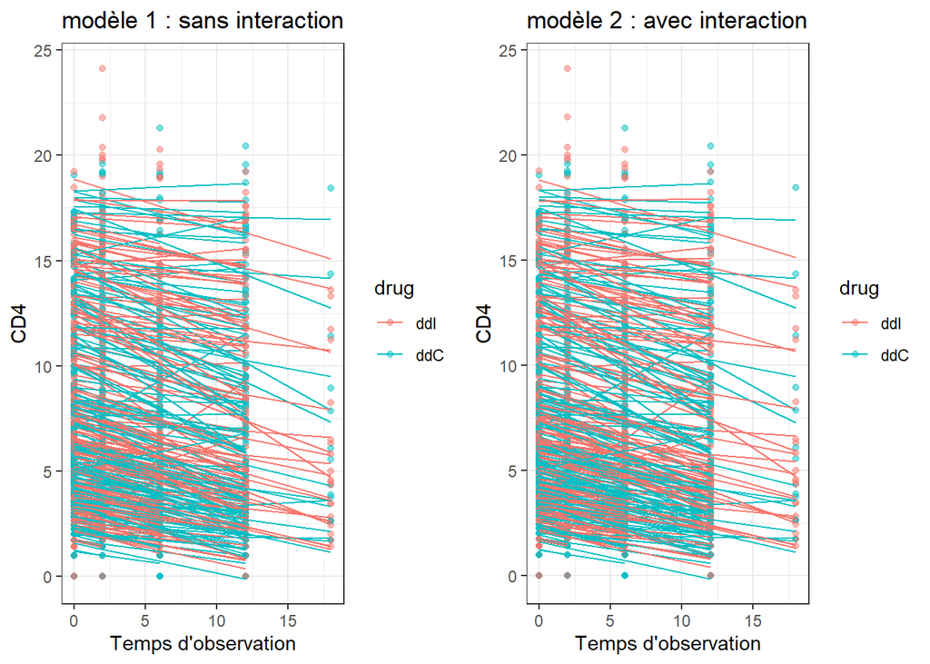

Ces graphiques montrent les trajectoires individuelles moyennes du nombre de CD4 pour chaque patients au cours du temps. Pour y voir plus clair on selectionne seulement quelques individus pour voir comment les modèles s’ajustent aux données d’après notre modèlisation.